# Cousera - Reproducible Research - Course Project 1

András Hosznyák

2018-05-06

# Loading and preprocessing the data

The first step is to load the data from the activity.csv. The summary shows that there are many empty values on the steps column.

```r
activity <- read.csv("activity.csv")
summary(activity)
```

```
##      steps                date          interval
##  Min.   :  0.00   2012-10-01:  288   Min.   :   0.0
##  1st Qu.:  0.00   2012-10-02:  288   1st Qu.: 588.8
##  Median :  0.00   2012-10-03:  288   Median :1177.5
##  Mean   : 37.38   2012-10-04:  288   Mean   :1177.5
##  3rd Qu.: 12.00   2012-10-05:  288   3rd Qu.:1766.2
##  Max.   :806.00   2012-10-06:  288   Max.   :2355.0
##  NA's   :2304     (Other)   :15840
```

# What is mean total number of steps taken per day?

## The total number of steps taken per day

Before analyse the total number of steps taken per day, have to aggregate the data by days in a new variable. For the summary, the maximum value of x axis and the frequency breaks can be set.

```r
activity_day_total <- with(activity, aggregate(steps, by = list(date), FUN = sum, na.rm = TRUE))
names(activity_day_total) <- c("date", "sum_of_step")
summary(activity_day_total)
```

```
##          date     sum_of_step
##  2012-10-01: 1   Min.   :    0
##  2012-10-02: 1   1st Qu.: 6778
##  2012-10-03: 1   Median :10395
##  2012-10-04: 1   Mean   : 9354
##  2012-10-05: 1   3rd Qu.:12811
##  2012-10-06: 1   Max.   :21194
##  (Other)   :55
```

## Histogram of the total number of steps taken each day

The histogram shows the frequency of the total number of steps taken each day.

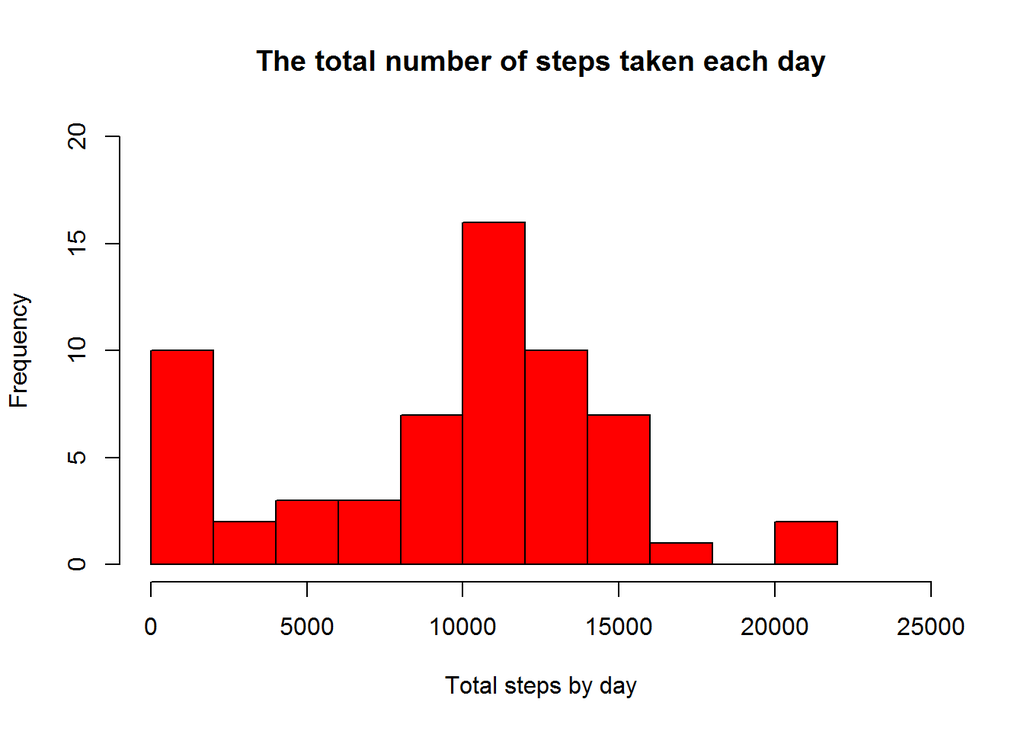

```r
hist(activity_day_total$sum_of_step, main = "The total number of steps taken each day", breaks = 15, xlab = "Total steps by day", col = "red", ylim = c(0,20), xlim = c(0,25000) )
```

## The mean and median of the total number of steps taken per day

The median of the total number of steps taken per day is the following:

```r
median(activity_day_total$sum_of_step)
```

```
## [1] 10395
```

The mean of the total number of steps taken per day is the following:

```r
mean(activity_day_total$sum_of_step)
```

```
## [1] 9354.23
```

# What is the average daily activity pattern?

Before analyse the mean number of steps taken per interval, have to average the data by interval in a new variable.

```r
activity_int_mean <- with(activity, aggregate(steps, by = list(interval), FUN = mean, na.rm = TRUE))
names(activity_int_mean) <- c("interval", "mean_of_step")
summary(activity_int_mean)
```

```
##     interval       mean_of_step
##  Min.   :   0.0   Min.   :  0.000
##  1st Qu.: 588.8   1st Qu.:  2.486
##  Median :1177.5   Median : 34.113
##  Mean   :1177.5   Mean   : 37.383
##  3rd Qu.:1766.2   3rd Qu.: 52.835
##  Max.   :2355.0   Max.   :206.170
```

## Time series of the average number of steps

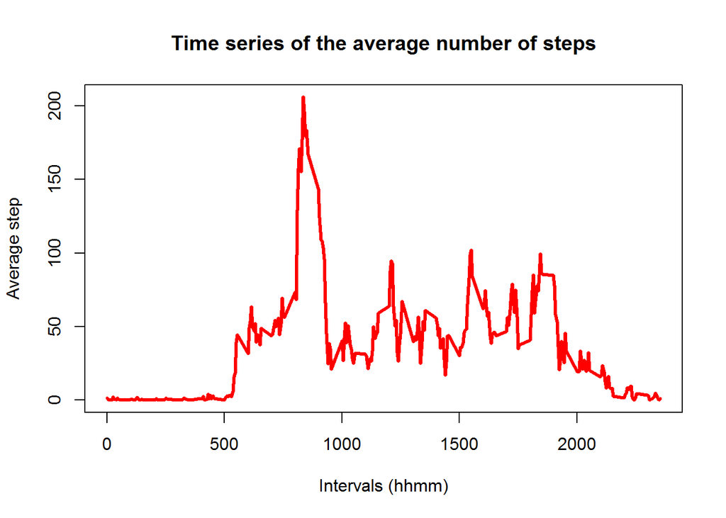

```r
plot(activity_int_mean$interval, activity_int_mean$mean_of_step, type = "l", lwd = 3, xlab = "Intervals (hhmm)", ylab = "Average step", main = "Time series of the average number of steps", col = "red")
```

## Which 5-minute interval contains the maximum number of steps?

```r
activity_int_mean[which.max(activity_int_mean$mean_of_step),]$interval
```

```
## [1] 835
```

# Imputing missing values

There are a number of days/intervals where there are missing values (coded as NA). The presence of missing days may introduce bias into some calculations or summaries of the data.

## The total number of rows with NA in the dataset

```r
na_index <- is.na(activity$steps)
sum(na_index)
```

```
## [1] 2304
```

## Devise a strategy for filling in all of the missing values in the dataset

```r
na_fill_mean <- mean(activity_int_mean$mean_of_step)
na_fill_mean
```

```
## [1] 37.3826
```

## Create a new dataset

Create a new dataset that is equal to the original dataset but with the missing data filled in.

```r
activity_fill <- activity
activity_fill[na_index, 1] <- na_fill_mean
head(activity_fill)
```

```
##     steps       date interval
## 1 37.3826 2012-10-01        0
## 2 37.3826 2012-10-01        5
## 3 37.3826 2012-10-01       10
## 4 37.3826 2012-10-01       15
## 5 37.3826 2012-10-01       20
## 6 37.3826 2012-10-01       25
```

```r
summary(activity_fill)
```

```
##      steps                date          interval
##  Min.   :  0.00   2012-10-01:  288   Min.   :   0.0
##  1st Qu.:  0.00   2012-10-02:  288   1st Qu.: 588.8
##  Median :  0.00   2012-10-03:  288   Median :1177.5
##  Mean   : 37.38   2012-10-04:  288   Mean   :1177.5
##  3rd Qu.: 37.38   2012-10-05:  288   3rd Qu.:1766.2
##  Max.   :806.00   2012-10-06:  288   Max.   :2355.0
##                   (Other)   :15840
```

## Aggregate the data for the histogram

```r
activity_fill_day_total <- with(activity_fill, aggregate(steps, by = list(date), FUN = sum, na.rm = TRUE))
names(activity_fill_day_total) <- c("date", "sum_of_step")
summary(activity_fill_day_total)
```

```
##          date     sum_of_step
##  2012-10-01: 1   Min.   :   41
##  2012-10-02: 1   1st Qu.: 9819
##  2012-10-03: 1   Median :10766
##  2012-10-04: 1   Mean   :10766
##  2012-10-05: 1   3rd Qu.:12811
##  2012-10-06: 1   Max.   :21194
##  (Other)   :55
```

## Histogram of the total number of steps taken each day

The histogram shows the frequency of the total number of steps taken each day.

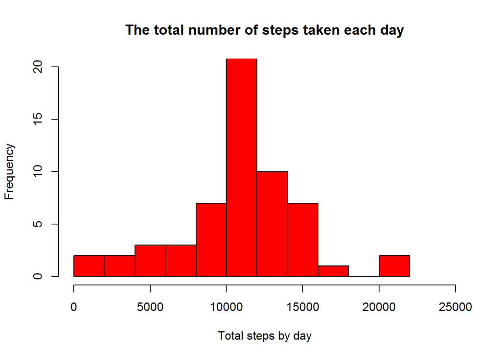

```r
hist(activity_fill_day_total$sum_of_step, main = "The total number of steps taken each day", breaks = 15, xlab = "Total steps by day", col = "red", ylim = c(0,20), xlim = c(0,25000) )
```

## The mean and median of the total number of steps taken per day

The median of the total number of steps taken per day is the following:

```r
median(activity_fill_day_total$sum_of_step)
```

```
## [1] 10766.19
```

The mean of the total number of steps taken per day is the following:

```r
mean(activity_fill_day_total$sum_of_step)
```

```
## [1] 10766.19
```

# Are there differences in activity patterns between weekdays and weekends?

## Create a new factor variable (weekday, weekend)

Creating a new factor variable - called weekday - With the weekdays and ifelse functions.

```r
activity_fill$day_name <- as.factor(weekdays(as.Date(activity_fill$date)))
activity_fill$weekday <- as.factor(ifelse(activity_fill$day_name == "szombat" | activity_fill$day_name == "vasárnap", "weekend", "weekday"))
```

## Time series plot for weekdays and weekends

The following plot shows the difference of the number of the average steps on weekdays or weekends.

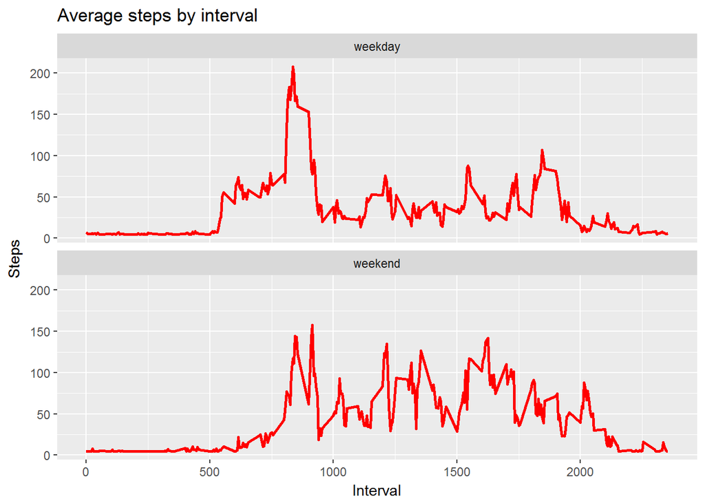

```r
activity_fill_weekday_mean <- with(activity_fill, aggregate(steps ~ weekday + interval, data = activity_fill, FUN = mean))

library(ggplot2)
plot <- ggplot(activity_fill_weekday_mean, aes(x = interval, y = steps)) +
            geom_line(size = 1, color = "red") +
            facet_wrap( ~ weekday, nrow = 2) +
            labs(title = "Average steps by interval", x = "Interval", y = "Steps")

plot
```